# Conexión CDM - Soluciones

Iniciación práctica en el análisis de datos OMOP

Author

Affiliation

Real World Epidemiology Group

IDIAP Jordi Gol

## Objetivo

El objetivo de esta práctica es conectarse a una base de datos sintética en formato *OMOP*, crear un objeto CDM y trabajar relacionando las diferentes tablas que nos ofrece.

## ¿Cómo funciona?

Utiliza este archivo para revisar y corregir tus soluciones. Ten en cuenta que no existe una única forma de resolver los ejercicios; si has llegado al mismo resultado utilizando otras funciones o enfoques, también es válido.

## Paquetes R

```r
renv::restore()
```

```
- The library is already synchronized with the lockfile.
```

```r
library(dplyr)
```

## Conexión Synthea

El siguiente código establece la conexión a la base de datos sintética. Deberás conectarte de la misma manera al inicio de cada práctica:

```r
db <- DBI::dbConnect(
  duckdb::duckdb(),
  CDMConnector::eunomiaDir("synthea-covid19-10k")
)
```

A partir de aquí, trabajamos como si se tratase de una base de datos real, por lo tanto lo que se ha visto en la parte teórica se puede aplicar.

## Conexión CDM

### Ejercicio 1

##### Crea el objeto cdm y utiliza sus tablas para responder las siguientes preguntas.

La información que nos falta para crear el objeto CDM es el nombre de los **schemes**. En estos caso, los dos se denominan “main”.

**Pista - OMOP**

Para crear el cdm a partir de una conexión disponemos de una función de la librería *CDMConnector*.

**Pista - Programación R**

Recuerda que para acceder a las tablas se utiliza `cdm$nombre_tabla`

```r
cdm <- CDMConnector::cdmFromCon(
  db,
  cdmSchema = "main",
  writeSchema = "main"
)
```

Una vez tenemos el objeto *cdm*, recomendamos acceder a algunas de las tablas para ver qué columnas y tipos de datos contiene. Por ejemplo, en la tabla “condition_ocurrence”, cada fila corresponde a un diagnóstico de una persona un determinado día. El código del diagnóstico lo encontramos en la columna *condition_concept_id*. Para saber a qué hace referencia este diagnostico, tenemos la tabla “concept” dónde por cada *concept_id* tenemos el *concept_name* que lo describe.

**Pista - OMOP**

En los siguientes ejercicios utilizarás funciones de la librería “omopgenerics”.

##### a) ¿Cuál es el nombre que lleva asignado el cdm?

```r
omopgenerics::cdmName(cdm)
```

```
[1] "Synthea"
```

##### b) ¿Qué tablas contiene el cdm que hemos creado?

```r
omopgenerics::listSourceTables(cdm)
```

```
 [1] "attribute_definition"  "care_site"             "cdm_source"
 [4] "cohort_definition"     "concept"               "concept_ancestor"
 [7] "concept_class"         "concept_relationship"  "concept_synonym"
[10] "condition_era"         "condition_occurrence"  "cost"
[13] "death"                 "device_exposure"       "domain"
[16] "dose_era"              "drug_era"              "drug_exposure"
[19] "drug_strength"         "fact_relationship"     "location"
[22] "measurement"           "metadata"              "note"
[25] "note_nlp"              "observation"           "observation_period"
[28] "payer_plan_period"     "person"                "procedure_occurrence"
[31] "provider"              "relationship"          "source_to_concept_map"
[34] "specimen"              "visit_detail"          "visit_occurrence"
[37] "vocabulary"
```

##### c) ¿Qué versión del cdm estamos utilizando?

```r
omopgenerics::cdmVersion(cdm)
```

```
[1] "5.3"
```

### Ejercicio 2

##### a) ¿A que corresponden los conceptos con códigos 8532, 45756772, 21600724, y 1123810?

```r
cdm$concept |>
  filter(concept_id %in% c(8532, 45756772, 21600724, 1123810)) |>
  select(concept_id, concept_name)
```

```
# Source:   SQL [?? x 2]
# Database: DuckDB 1.4.4 [agiuliodori@Windows 10 x64:R 4.4.0/C:\Users\agiuliodori\AppData\Local\Temp\RtmpiSn1l2\file27ec4a3093f.duckdb]
  concept_id concept_name
       <int> <chr>
1   45756772 Epilepsy
2    1123810 naloxone; systemic (peripheral opioid receptor antagonists)
3   21600724 insulin (beef); parenteral (insulins and analog. for injection, in…
4       8532 FEMALE
```

**Pista - OMOP**

Los códigos del enunciado corresponden a *concept_id* de la tabla concept.

**Pista - Programación R**

La función `filter()` del paquete dplyr permite filtrar la tabla según el contenido de una columna. Por ejemplo, para obtener la persona con person_id 10 hacemos:

```r
cdm$person |> filter(person_id == 10)
```

```
# Source:   SQL [?? x 18]
# Database: DuckDB 1.4.4 [agiuliodori@Windows 10 x64:R 4.4.0/C:\Users\agiuliodori\AppData\Local\Temp\RtmpiSn1l2\file27ec4a3093f.duckdb]
  person_id gender_concept_id year_of_birth month_of_birth day_of_birth
      <int>             <int>         <int>          <int>        <int>
1        10              8507          2010              3            7
# ℹ 13 more variables: birth_datetime <dttm>, race_concept_id <int>,
#   ethnicity_concept_id <int>, location_id <int>, provider_id <int>,
#   care_site_id <int>, person_source_value <chr>, gender_source_value <chr>,
#   gender_source_concept_id <int>, race_source_value <chr>,
#   race_source_concept_id <int>, ethnicity_source_value <chr>,
#   ethnicity_source_concept_id <int>
```

##### b) ¿Cuántas personas registradas como mujer hay en la base de datos?

```r
cdm$person |>
  filter(gender_concept_id == 8532) |>
  tally()
```

```
# Source:   SQL [?? x 1]
# Database: DuckDB 1.4.4 [agiuliodori@Windows 10 x64:R 4.4.0/C:\Users\agiuliodori\AppData\Local\Temp\RtmpiSn1l2\file27ec4a3093f.duckdb]
      n
  <dbl>
1  5165
```

**Pista - OMOP**

La tabla “person” contiene información sobre el sexo de los pacientes.

**Pista - Programación R**

La función `tally()` del paquete dplyr cuenta el número de filas.

##### c) ¿Cuando empieza y acaba el registro de los datos?

```r
# inicio
cdm$observation_period |>
  filter(observation_period_start_date == min(observation_period_start_date)) |>
  distinct(observation_period_start_date)
```

```
# Source:   SQL [?? x 1]
# Database: DuckDB 1.4.4 [agiuliodori@Windows 10 x64:R 4.4.0/C:\Users\agiuliodori\AppData\Local\Temp\RtmpiSn1l2\file27ec4a3093f.duckdb]
  observation_period_start_date
  <date>
1 1923-12-29
```

```r
# final
cdm$observation_period |>
  filter(observation_period_end_date == max(observation_period_end_date)) |>
  distinct(observation_period_end_date)
```

```
# Source:   SQL [?? x 1]
# Database: DuckDB 1.4.4 [agiuliodori@Windows 10 x64:R 4.4.0/C:\Users\agiuliodori\AppData\Local\Temp\RtmpiSn1l2\file27ec4a3093f.duckdb]
  observation_period_end_date
  <date>
1 2023-06-14
```

**Pista - OMOP**

La tabla “observation_period” contiene información sobre cuando empieza (observation_period_start_date) y cuando acaba (observation_period_end_date) el seguimiento clínico de cada persona. Para responder a la pregunta, podemos mirar cual es el *start date* más pequeño y cual es el *end date* más grande.

**Pista - Programación R**

Para obtener, por ejemplo, las filas que contengan el máximo de un valor, hacemos lo siguiente:

```r
# tabla
tabla <- tibble(nombres = c("Joan", "Marta", "Lluís", "Mireia"), puntuacion = c(2, 4, 4, 3))

# filtramos los que tengan mayor puntuación
tabla |> filter(puntuacion == max(puntuacion))
```

```
# A tibble: 2 × 2
  nombres puntuacion
  <chr>        <dbl>
1 Marta            4
2 Lluís            4
```

Para obtener el mínimo, utilizaríamos la función `min()`.

## Relación entre tablas del CDM

### Ejercicio 3

##### a) ¿Cuántos hombres de la base de datos están muertos?

**Pista - OMOP**

Tendremos que utilizar la tabla “person” y la tabla “death”. El *gender_concept_id = 8507* identifica a aquellas personas registradas como hombre en la base de datos.

**Pista - Programación R**

La función *“inner_join()”* de dplyr nos permite combinar dos tablas a partir de una clave común (en este caso el “person_id”). Solo aquellos person_id que aparezcan en ambas tablas serán considerados.

```r
person <- tibble(
  person_id = c(1, 2, 3, 4),
  sex = c("Male", "Female", "Female", "Male")
)

death <- tibble(
  person_id = c(2, 4, 5),
  death_date = as.Date(c("2020-01-10", "2021-03-05", "2019-12-01"))
)

inner_join(death, person, by = "person_id")
```

```
# A tibble: 2 × 3
  person_id death_date sex
      <dbl> <date>     <chr>
1         2 2020-01-10 Female
2         4 2021-03-05 Male
```

```r
cdm$death |>
  inner_join(
    cdm$person |> filter(gender_concept_id == 8507),
    by = c("person_id")
  ) |>
  tally()
```

```
# Source:   SQL [?? x 1]
# Database: DuckDB 1.4.4 [agiuliodori@Windows 10 x64:R 4.4.0/C:\Users\agiuliodori\AppData\Local\Temp\RtmpiSn1l2\file27ec4a3093f.duckdb]
      n
  <dbl>
1   614
```

##### b) ¿Cuáles son las diferentes causas de muerte en la base de datos?

**Pista - OMOP**

La tabla “death” contiene una columna que indica la causa de muerte. La función *colnames(cdm$death)* te permitirá ver las columnas de la tabla.

**Pista - Programación R**

Puedes usar la función *distinct()* de dplyr para ver los valores únicos de una columna. Si quisieras agregar el concept_name de cada causa de muerte, puedes usar la función *left_join()* que mantiene TODAS las filas de la tabla de la izquierda, y añade información de la tabla de la derecha solo cuando hay coincidencia en la clave.

```r
cdm$death |>
  distinct(cause_concept_id) |>
  left_join(
    cdm$concept |> select(concept_id , concept_name),
    by = c("cause_concept_id" = "concept_id")
  )
```

```
# Source:   SQL [?? x 2]
# Database: DuckDB 1.4.4 [agiuliodori@Windows 10 x64:R 4.4.0/C:\Users\agiuliodori\AppData\Local\Temp\RtmpiSn1l2\file27ec4a3093f.duckdb]
  cause_concept_id concept_name
             <int> <chr>
1          4329847 Myocardial infarction
2           381316 Cerebrovascular accident
3         37311061 COVID-19
4           321042 Cardiac arrest
```

##### c) ¿Cuántos hombres han muerto por cada causa?

**Pista - Programación R**

La función *group_by()* seguida de la función *tally()* te permitirá contar el número de eventos por cada grupo.

```r
cdm$death |>
  inner_join(
    cdm$person |> filter(gender_concept_id == 8507),
    by = c("person_id")
  ) |>
  group_by(cause_concept_id) |>
  tally()
```

```
# Source:   SQL [?? x 2]
# Database: DuckDB 1.4.4 [agiuliodori@Windows 10 x64:R 4.4.0/C:\Users\agiuliodori\AppData\Local\Temp\RtmpiSn1l2\file27ec4a3093f.duckdb]
  cause_concept_id     n
             <int> <dbl>
1         37311061    30
2          4329847   395
3           381316    92
4           321042    97
```

## SQL i R

**R:** Es un lenguaje amigable para el usuario. Dispone de paquetes que permiten realizar la mayor parte de los análisis estadísticos que necesitamos, y ofrece pedidos sencillos para gestionar tablas y datos (tidyverse). Sin embargo, R opera completamente en memoria, lo cual acontece un problema cuando se trabaja con bases de datos extensas como por ejemplo los registros electrónicos de salud.

**SQL:** Es un lenguaje de consulta de bases de datos, diseñado específicamente para almacenar, gestionar e interactuar con una base de datos. SQL es muy útil para resolver problemas de memoria cuando se trabaja con bases de datos, puesto que opera al “lado de la base de datos”, los datos se encuentran en el server y no en la memoria RAM (en la cual R opera). No obstante, algunas operaciones estadísticas no son posibles en SQL, o al menos son extremadamente difíciles y enrevesadas.

Lo que hace el paquete *dbplyr* es traducir nuestros pedidos R en SQL, de forma que se ejecutan al “lado de la base de datos” y desprendido nosotros podemos ver el resultado en RStudio. A continuación, introducimos 3 funciones importantes y algunos aspectos a tener en cuenta.

#### compute()

[compute](https://dplyr.tidyverse.org/reference/compute.html): se utiliza para forzar la computación de un conjunto de pedidos. Si no se utiliza “compute”, nuestra variable solo contiene el conjunto de comandos SQL que se tienen que ejecutar, y no la tabla resultante. Se recomienda utilizarlo al final de cada conjunto de operaciones, puesto que así cuando se llame la variable en un futuro, estaremos llamando a la tabla resultante y no a un conjunto de comandos que se tendrán que ejecutar cada vez.

```r
table7 <- cdm$person |>
  inner_join(cdm$observation_period) |>
  select(person_id, year_of_birth, observation_period_start_date, observation_period_end_date) |>
  compute()
table7
```

```
# Source:   table<og_001_1772803212> [?? x 4]
# Database: DuckDB 1.4.4 [agiuliodori@Windows 10 x64:R 4.4.0/C:\Users\agiuliodori\AppData\Local\Temp\RtmpiSn1l2\file27ec4a3093f.duckdb]
   person_id year_of_birth observation_period_start_date observation_period_en…¹
       <int>         <int> <date>                        <date>
 1         1          1970 2014-05-09                    2023-05-12
 2         2          1929 1977-04-11                    1986-09-15
 3         3          1970 2014-04-19                    2023-04-22
 4         4          1966 2014-03-22                    2023-04-08
 5         5          1936 2013-11-13                    2023-01-04
 6         6          1996 2013-07-17                    2021-08-04
 7         7          1923 2013-06-26                    2022-08-17
 8         8          2018 2018-08-20                    2022-07-25
 9         9          1933 2013-08-03                    2022-09-24
10        10          2010 2013-08-11                    2023-04-02
# ℹ more rows
# ℹ abbreviated name: ¹observation_period_end_date
```

#### collect()

[collect](https://dplyr.tidyverse.org/reference/compute.html): se utiliza para mover un conjunto de datos desde el lado de la base de datos a nuestro entorno R. Típicamente haremos todas las operaciones posibles junto a la base de datos, y cuando llegue el momento de hacer algún análisis (por ejemplo, ajustar una regresión Cox), utilizaremos collect() para mover la tabla al entorno R.

Fíjate que en la salida siguiente, después de utilizar “collect()”, la tabla aparece como un tibble en lugar de SQL, como aparecía antes (parte superior de la tabla de salida).

```r
table8 <- table7 |>
  filter(year_of_birth > 2010) |>
  collect()
table8
```

```
# A tibble: 1,331 × 4
   person_id year_of_birth observation_period_start_date observation_period_en…¹
       <int>         <int> <date>                        <date>
 1         8          2018 2018-08-20                    2022-07-25
 2        17          2011 2013-10-31                    2022-12-08
 3        27          2017 2017-05-10                    2023-04-26
 4        31          2016 2016-04-14                    2023-04-06
 5        34          2013 2013-06-24                    2023-01-23
 6        36          2016 2016-09-28                    2022-09-14
 7        38          2021 2021-07-08                    2022-12-15
 8        46          2014 2014-10-18                    2022-10-15
 9        59          2013 2013-07-24                    2022-06-22
10        70          2012 2013-08-27                    2022-06-29
# ℹ 1,321 more rows
# ℹ abbreviated name: ¹observation_period_end_date
```

#### pull()

[pull](https://dplyr.tidyverse.org/reference/pull.html): se utiliza para obtener una columna de un conjunto de datos de la tabla. Por ejemplo, si queremos un listado de todas los *person_id* de la tabla person.

```r
person_id <- cdm$person |> pull("person_id")
person_id[1:20]
```

```
 [1]  1  2  3  4  5  6  7  8  9 10 11 12 13 14 15 16 17 18 19 20
```

### Ejercicio 4

##### a) ¿Cuándo es el primer diagnóstico de COVID registrado con el concept_id = 37311061 en la base de datos? ¿En qué tipo de consulta se realizó (urgencia, hospitalización o externa)?

**Pista - OMOP**

Los diagnósticos de salud se registran en la tabla “condition_occurrence”. El tipo de visita se registra en la tabla “visit_occurrence” (columna: visit_concept_id).

**Pista - Programación R**

Puedes comenzar creando una tabla con los diagnósticos de covid, utilizando un `compute()`. Combina la función `filter()` con `min()` para encontrar el primer diagnóstico. Luego utiliza un `left_join()` utilizando la clave “visit_occurrence_id”.

```r
covid_diagnostics <- cdm$condition_occurrence |>
  filter(condition_concept_id == 37311061) |>
  select(condition_occurrence_id, person_id, condition_start_date, condition_end_date, visit_occurrence_id) |>
  compute()


covid_diagnostics |>
  filter(condition_start_date == min(condition_start_date)) |>
  left_join(
    cdm$visit_occurrence |> select(visit_occurrence_id, visit_concept_id),
    by = c("visit_occurrence_id")
  ) |>
  left_join(
    cdm$concept, by = c("visit_concept_id" = "concept_id")
  ) |>
  select(person_id, condition_start_date, visit_concept_id, concept_name)
```

```
# Source:   SQL [?? x 4]
# Database: DuckDB 1.4.4 [agiuliodori@Windows 10 x64:R 4.4.0/C:\Users\agiuliodori\AppData\Local\Temp\RtmpiSn1l2\file27ec4a3093f.duckdb]
  person_id condition_start_date visit_concept_id concept_name
      <int> <date>                          <int> <chr>
1      3705 2020-03-15                       9202 Outpatient Visit
```

##### b) ¿Cuántas personas tienen un registro de COVID (concept_id = 37311061) antes del 1 de enero de 2021? De estos registros, ¿cuántas corresponden a personas registradas como mujer?

**Pista - Programación R**

Para definir una fecha utilizar la función as.Date(): `as.Date("2021-06-01")`.

```r
covid_diagnostics |>
  filter(condition_start_date < as.Date("2021-01-01")) |>
  tally()
```

```
# Source:   SQL [?? x 1]
# Database: DuckDB 1.4.4 [agiuliodori@Windows 10 x64:R 4.4.0/C:\Users\agiuliodori\AppData\Local\Temp\RtmpiSn1l2\file27ec4a3093f.duckdb]
      n
  <dbl>
1   578
```

```r
covid_diagnostics |>
  filter(condition_start_date < as.Date("2021-01-01")) |>
  inner_join(
    cdm$person |> filter(gender_concept_id == 8532) |> select(person_id),
    by="person_id"
  ) |>
 tally()
```

```
# Source:   SQL [?? x 1]
# Database: DuckDB 1.4.4 [agiuliodori@Windows 10 x64:R 4.4.0/C:\Users\agiuliodori\AppData\Local\Temp\RtmpiSn1l2\file27ec4a3093f.duckdb]
      n
  <dbl>
1   285
```

##### c) ¿A cuántos individuos diagnosticados con COVID (con concept_id 37311061) le administraron oxígeno el mismo día del diagnóstico (concept_id = 4162736)?

**Pista - OMOP**

Los procedimientos se registran en la tabla “procedure_occurrence”.

**Pista - Programación R**

Puedes hacer un join con más de una clave (ejemplo: person_id y start_date).

```r
covid_diagnostics |>
  inner_join(
    cdm$procedure_occurrence |> filter(procedure_concept_id == 4162736),
    by = c("person_id", "condition_start_date" = "procedure_date")
  ) |>
  tally()
```

```
# Source:   SQL [?? x 1]
# Database: DuckDB 1.4.4 [agiuliodori@Windows 10 x64:R 4.4.0/C:\Users\agiuliodori\AppData\Local\Temp\RtmpiSn1l2\file27ec4a3093f.duckdb]
      n
  <dbl>
1   159
```

##### d) ¿Qué otros procedimientos se registraron a la fecha de diagnóstico de COVID?

```r
covid_diagnostics|>
  inner_join(
    cdm$procedure_occurrence,
    by = c("person_id", "condition_start_date" = "procedure_date")
  ) |>
  distinct(procedure_concept_id) |>
  left_join(
    cdm$concept |> select(concept_id, concept_name),
    by = c("procedure_concept_id" ="concept_id")
  )
```

```
# Source:   SQL [?? x 2]
# Database: DuckDB 1.4.4 [agiuliodori@Windows 10 x64:R 4.4.0/C:\Users\agiuliodori\AppData\Local\Temp\RtmpiSn1l2\file27ec4a3093f.duckdb]
  procedure_concept_id concept_name
                 <int> <chr>
1              4162736 Oxygen administration by mask
2              4163872 Plain chest X-ray
3              4196006 Placing subject in prone position
```

## Ejercicios extra

### Ejercicio 5

##### De las personas con un diagnóstico de COVID, ¿cuántos tuvieron una prescripción de paracetamol desde la fecha de diagnóstico a los 15 días posteriores?

**Pista - OMOP**

La tabla donde puedes encontrar información de precripciones de medicamentos es la “drug_exposure”. El concept_id del paracetamol es 19020053 (concept_name = acetaminophen 500 MG Oral Tablet)

**Pista - Programación R**

Puede que haya más de una prescripción durante ese período de tiempo por cada individuo; hará falta filtrar la primera prescipción de cada uno.

```r
covid_paracetamol_db <- covid_diagnostics |>
  inner_join(
    cdm$drug_exposure |> filter(drug_concept_id == 19020053) |> select(person_id, drug_exposure_start_date)
  ) |>
  filter(
    drug_exposure_start_date >= condition_start_date &
    drug_exposure_start_date <= condition_start_date + lubridate::days(15)
  ) |>
  group_by(person_id, condition_start_date) |>
  filter(drug_exposure_start_date == min(drug_exposure_start_date)) |>
  ungroup() |>
  compute()

# Número de registros
covid_paracetamol_db |> tally()
```

```
# Source:   SQL [?? x 1]
# Database: DuckDB 1.4.4 [agiuliodori@Windows 10 x64:R 4.4.0/C:\Users\agiuliodori\AppData\Local\Temp\RtmpiSn1l2\file27ec4a3093f.duckdb]
      n
  <dbl>
1   164
```

**Pasos**

1. Filtra la tabla *drug* exposure para obtener únicamente los eventos de paracetamol.
2. Une la tabla con diagnósticos que has creado en el ejercicio anterior con la tabla drug_exposure filtrada.
3. Filtra la tabla resultante para obtener solo las presecripciones de paracetamol que se dieron desde que el paciente tenía COVID-19 hasta 15 días posteriores (*cohort_start_date* hasta *cohort_end_date*).
4. Eliminar los duplicados de las prescripciones (por ejemplo, quedándonos con la primera).

### Ejercicio 6

##### Representa el número de diagnósticos COVID-19 mensuales por año en un diagrama de barras.

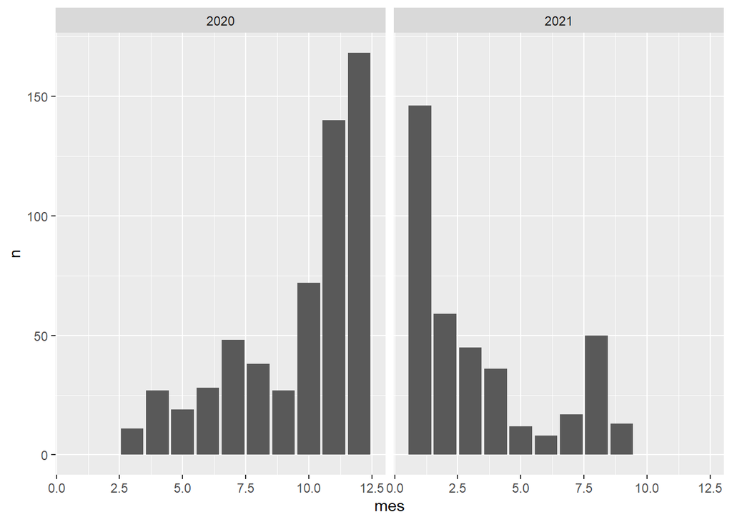

```r
library(ggplot2)

covid_any <- covid_diagnostics |>
  mutate(mes = lubridate::month(condition_start_date),
         any = lubridate::year(condition_start_date)) |>
  group_by(mes, any) |>
  tally() |>
  ungroup() |>
  collect()

# plot
covid_any |>
  ggplot(aes(x = mes, y = n)) +
  geom_col() +
  facet_wrap(any ~ .)
```

**Ten en cuenta:**

- Para extraer el mes y el año de una fecha puedes utilizar las funciones `month` y `year` del paquete lubridate.
- No se puede realizar una gráfica con datos que están en el server, hará falta hacer `collect()` antes.
- Para hacer el gráfico necesitarás crear una tabla con los números de casos por mes y año.
- Puedes utilizar la librería `ggplot2` para realizar la gráfica.

### Ejercicio 7

Calcular un resumen estadístico del año de nacimiento de todos los individuos del cdm, estratificado por sexo. Representar gráficamente la distribución del año de nacimiento por sexo mediante un diagrama de caja (boxplot).

**Pista - Programación R**

Para cada grupo, obtener el mínimo, primer cuartil (Q25), mediana, tercer cuartil (Q75) y máximo mediante la función `summarise()`. Recuerda hacer un collect() para poder graficar.

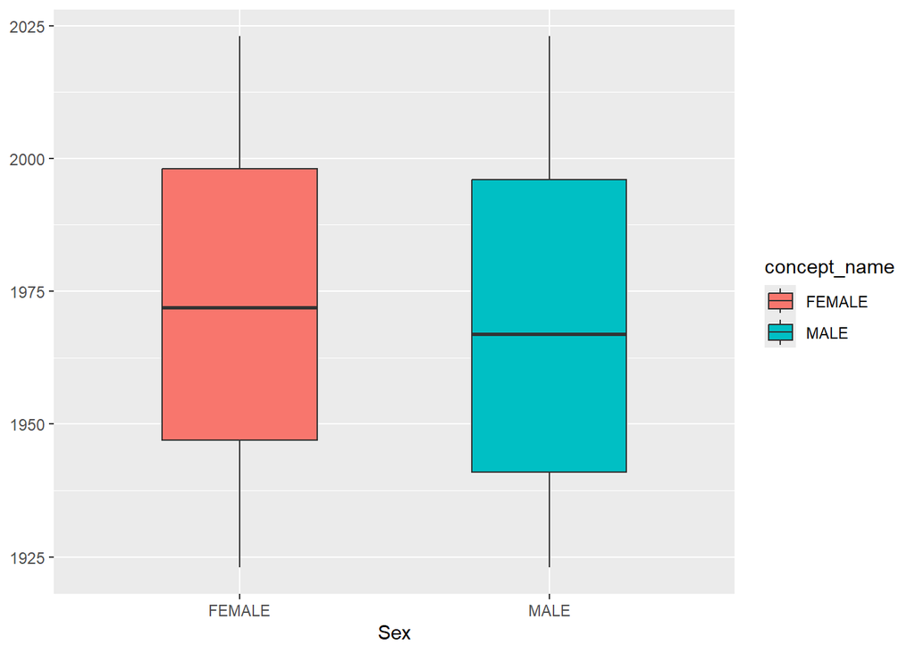

```r
sex_birth_summary <- cdm$person |>
  group_by(gender_concept_id) |>
  summarise(
    min_year_of_birth = min(year_of_birth, na.rm = TRUE),
    q25_year_of_birth = quantile(year_of_birth, 0.25, na.rm = TRUE),
    median_year_of_birth = median(year_of_birth, na.rm = TRUE),
    q75_year_of_birth = quantile(year_of_birth, 0.75, na.rm = TRUE),
    max_year_of_birth = max(year_of_birth, na.rm = TRUE)
  ) |>
  left_join(
    cdm$concept |> select(concept_id, concept_name),
    by = c("gender_concept_id" = "concept_id")
  ) |>
  collect()

sex_birth_summary |>
  ggplot(mapping = aes(
    x = concept_name,
    group = concept_name,
    fill = concept_name
  )) +
  geom_boxplot(
    mapping = aes(
      lower = q25_year_of_birth,
      upper = q75_year_of_birth,
      middle = median_year_of_birth,
      ymin = min_year_of_birth,
      ymax = max_year_of_birth
    ),
    stat = "identity", width = 0.5
  ) +
  xlab("Sex")
```

## Desconexión del CDM

Recuerda desconectarte del servidor una vez hayas acabado los análisis.

```r
CDMConnector::cdmDisconnect(cdm)
```

## Consejos de optimización de código:

- Prioriza joins (inner, left, right, anti) sobre filtros
- Ejecuta las operaciones en la base de datos siempre que sea posible
- Evita cambiar innecesariamente entre BD y R
- Usa `compute()` cuando quieras materializar (y re-utilizar) resultados intermedios
- Usa `collect()` solo cuando realmente necesites los datos en memoria